# Simulation and Optimisation

R Foundations 2025

Ella Kaye, Department of Statistics

October 31, 2025

## Overview

- Numerical precision
- Random numbers
- Simulation
- Optimisation

This material is largely reproduced from [Ruth Ripley’s 2013 APTS course](https://portal.stats.ox.ac.uk/userdata/ruth/APTS2013/Rcourse5.pdf)

# Numerical precision

## How R stores numbers

Some basic understanding is needed of how R stores and does arithmetic on numbers to avoid being surprised by the results it gives.

From the R FAQ:

> The only numbers that can be represented exactly in R’s numeric type are integers and fractions whose denominator is a power of 2. Other numbers have to be rounded to (typically) 53 binary digits accuracy. As a result, two floating point numbers will not reliably be equal unless they have been computed by the same algorithm, and not always even then.

## Example

```r
a <- sqrt(2)
a * a == 2
```

```
[1] FALSE
```

```r
a * a - 2
```

```
[1] 4.440892e-16
```

```r
all.equal(a * a, 2)
```

```
[1] TRUE
```

The function `all.equal()` compares two objects using a numeric tolerance of `.Machine$double.eps^0.5`.<sup>1</sup> If you want much greater accuracy than this you will need to consider error propagation carefully.

[^1]: `.Machine$double.eps` is the smallest positive floating-point number `x` such that `1 + x != 1` on the machine R is running on.

## Numerical consideration resources

For more information, see e.g.

- David Goldberg (1991), “What Every Computer Scientist Should Know About Floating-Point Arithmetic”, *ACM Computing Surveys*, **23/1**, 5–48, also available via https://docs.oracle.com/cd/E19957-01/806-3568/ncg_goldberg.html.
- Ruth Ripley’s [numerical considerations](https://portal.stats.ox.ac.uk/userdata/ruth/APTS2013/Numerics.pdf) notes for APTS 2013.

# Simulation

## Uses of simulation

- Statistical models are often mathematically intractable
- Generate multiple samples for a model by simulation
- Use these samples to investigate the behaviour of the model
- Need realisations of random variables with various different distributions, our *random numbers*
- Details of how to use the random numbers to create samples will not be considered here

## Random number generation

- Random numbers calculated on a computer are not random.
- They are *pseudo-random*, following a predicted sequence, but in the short-term (i.e. anything but the *very* long-term) will appear to be random.
- This is useful, as two sets of random numbers of the same size from the same generator using the same initial value will be exactly the same. **This is crucial for reproducibility.**
- R provides functions for generating random samples from standard distibutions.

## Random seeds in R

- Each time a random number is required, R will use and update a variable called `.Random.seed` which is in your workspace.
- At the first use, if `.Random.seed` does not exist, one will be created, with a value generated from the time.
- The function `set.seed(n)` will set `.Random.seed` to a value derived from the argument `n`.
- Use `set.seed()` to repeat the same sequence of random numbers.

## `set.seed()` example

```r
sample(10)
```

```
 [1]  8  4  3 10  1  5  9  7  2  6
```

```r
set.seed(1)
sample(10)
```

```
 [1]  9  4  7  1  2  5  3 10  6  8
```

```r
sample(10)
```

```
 [1]  3  1  5  8  2  6 10  9  4  7
```

```r
set.seed(1)
sample(10)
```

```
 [1]  9  4  7  1  2  5  3 10  6  8
```

## `sample()`

The `sample()` function re-samples from a data vector, with or without replacement.

`sample(x, size, replace = FALSE, prob = NULL)`

| `x` | positive integer or a vector |
| --- | --- |
| `size` | non-negative integer, number of items to choose |
| `replace` | logical - should sampling be with replacement |
| `prob` | a vector of probability weights for obtaining the elements of the vector being sampled. |

## `sample()` examples

- `sample(n)`
- `sample(x)`
- `sample(x, replace = TRUE)`
- `sample(x, size = n)`
- `sample(x, n, replace = TRUE)`
- `sample(x, n, replace = TRUE, prob = probs)`

A random permutation of 1, …, n

```r
set.seed(123)
sample(10)
```

```
 [1]  3 10  2  8  6  9  1  7  5  4
```

See also `sample.int()`:

```r
set.seed(123)
sample.int(10)
```

```
 [1]  3 10  2  8  6  9  1  7  5  4
```

A random permutation of `x` for `length(x) > 1`

```r
set.seed(10)
alph5 <- LETTERS[1:5]
sample(alph5)
```

```
[1] "C" "A" "B" "E" "D"
```

A bootstrap sample

```r
set.seed(10)
sample(alph5, replace = TRUE)
```

```
[1] "C" "A" "B" "D" "C"
```

Sample `n` items from `x` without replacement

```r
set.seed(10)
sample(alph5, 3)
```

```
[1] "C" "A" "B"
```

Sample `n` items from `x` with replacement

```r
set.seed(1)
sample(alph5, 3, replace = TRUE)
```

```
[1] "A" "D" "A"
```

Probability sample of `n` items from `x`

```r
x <- 1:4
probs <- c(1/2, 1/3, 1/12, 1/12)

set.seed(1)
samp <- sample(x, 100, replace = TRUE, prob = probs)
table(samp)
```

```
samp
 1  2  3  4
52 34 10  4
```

## Distributions in R

Many statistical distributions are built into R. Each has a root name, e.g. `norm` for the normal distribution.

There are four functions for each distribution, with different letters prefixing the root name:

- `p` for *probability*, the cumulative distribution function
- `q` for *quantile*, the inverse c.d.f.
- `d` for *density*, the density function, p.d.f.
- `r` for *random*, a random sample from the distribution.

So, for the normal distribution, we have the functions `pnorm`, `qnorm`, `dnorm`, `rnorm`.

## Distributions and parameterisations

| Distribution | Base name | Parameters |
| --- | --- | --- |
| beta | `beta` | `shape1`, `shape2` |
| binomial | `binom` | `size`, `prob` |
| Cauchy | `cauchy` | `location`, `scale` |
| chi-squared | `chisq` | `df` |
| exponential | `exp` | `rate` |
| F | `f` | `df1`, `df2` |
| gamma | `gamma` | `shape`, `rate` |
| geometric | `geom` | `p` |
| hypergeometric | `hyper` | `m`, `n`, `k` |
| log-normal | `lnorm` | `meanlog`, `sdlog` |
| logistic | `logis` | `location`, `scale` |
| negative binomial | `nbinom` | `size`, `prob` |
| normal | `norm` | `mean`, `sd` |
| Poisson | `pois` | `lambda` |
| Student t | `t` | `df` |
| uniform | `unif` | `min`, `max` |
| Weibull | `weibull` | `shape`, `scale` |

## Generating random samples from a distibution

To obtain a sample of size `n`, use the `r` function for the distribution with the first argument `n`, and subsequent arguments the parameters for that distribution. The parameters often have default values. E.g.

| `runif(n, min=0, max=1)` | Uniform |
| --- | --- |
| `rnorm(n, mean=0, sd=1)` | Normal |
| `rexp(n, rate=1)` | Exponential with mean 1/rate |
| `rt(n, df)` | t with df degrees of freedom |
| `rbinom(n, size, prob)` | Binomial, success in `size` trials with probability of success `prob` |

Table from https://www.johndcook.com/blog/distributions_r_splus/

## Your turn!

Sometimes `sample()` can lead to nasty surprises.

Consider the following code. Which line(s) might cause a problem?

```r
x <- 1:10
sample(x[x > 7])
sample(x[x > 8])
sample(x[x > 9])
sample(x[x > 10])
```

Run the code to see what happens.

**Warning**

You need to be careful when using `sample()` programmatically (i.e. in your function or simulation).

See `?sample` for a safer version and check you understand how the proposed `resample()` function in the examples works.

# Optimisation

## The optimisation problem

- Given a function $f(x)$, what value of $x$ makes $f(x)$ as small or large as possible?
- In a statistical context, $x$ will usually be the parameters of a model, and $f(x)$ either the model likelihood to be maximised or some measure of discrepancy between data and predictions to be minimised
- The optimal set of parameters will give the *best fit*
- Only need to consider *small* as $-f(x)$ is *large* when $f(x)$ is *small*.
- We consider here *general-purpose optimisers*

## Local and global minima

- The (negative of the) likelihood for the General Linear Model (and that for many other linear models) is well-behaved: it has a single, global minimum.
- For more complicated models there may be many local minima.
- Finding a global minimum is difficult, and not always important. Only if local minima are widely separated in parameter space are they likely to invalidate our conclusions.
- We will concentrate on methods of finding local minima. Check for different local minima by altering the initial values, algorithm used, or other parameters of the fitting process.

## Univariate optimisation

`optimize` (or `optimise`) finds a (possibly local) mimimum of a function in a specified interval with respect to its first argument.

- Function to be minimised is the first argument to `optimize`
- Can pre-specify the function or include it in the command.

## Univariate optimisation: example

```r
f <- function(x, a) {
  (x - a)^2
}

xmin <- optimize(f, interval = c(0, 1), a = 1/3)

# or

xmin <- optimize(function(x, a) {(x - a)^2},
                 interval = c(0, 1), a = 1/3)

xmin
```

```
$minimum
[1] 0.3333333

$objective
[1] 0
```

Note how the (fixed) parameter `a` is passed into `f`.

## Other `optimize()` arguments

- An interval within which to search must be specified, either by `interval` or by `upper` and `lower`
- To *maximise* set `maximum = TRUE`
- Accuracy can be set using the `tol` argument
- Note the order of arguments: `optimize(f, interval, ..., lower, upper, maximum, tol)`
- The `...` can be named or unnamed and will be passed to `f`
- Arguments after the `...` must be specified by names.
- `optimize` returns a list with two items:
  - `minimum`: the value of `x` at which `f(x)` is minimised
  - `objective`: the value of `f(x)` at `x = minimum`

## General optimisation

- In more than one dimension the problem is harder.
- R has several different functions: most flexible is `optim()` which includes several different algorithms.
- Algorithm of choice depends on how easy it is to calculate derivatives for the function. Usually better to supply a function to calculate derivatives, but may be unnecessary extra work.
- Ensure the problem is scaled so that unit change in any parameter gives approximately unit change in objective.

## How to use `optim()`

`optim(par, fn, gr=NULL, ..., method=c("Nelder-Mead", "BFGS", "CG", "L-BFGS-B", "SANN", "Brent"), lower=-Inf, upper=Inf, control=list(), hessian=FALSE)`

| `par` | starting values of the parameters |
| --- | --- |
| `fn` | function to be optimised (supply as for `optimize`) |
| `gr` | function to calculate the derivative, only relevant for methods “BFGS”, “CG” or “L-BFGS-B” |
| `…` | other parameters for (both) `fn` and `gr` |
| `method` | algorithm to use |
| `lower`, `upper` | vector of limits for parameters (only allowed it `method="L-BFGS-B"` |
| `control` | control options (see next slide) |
| `hessian` | logical: whether to return a hessian estimate calculated by finite differences |

## `optim()`: control options

There are very many. The most important are:

| `trace` | A positive integer: higher values give more information |
| --- | --- |
| `fnscale` | An overall scaling: if negative, maximisation will be performed |
| `parscale` | A vector of scalings for the parameters |
| `maxit` | Maximum number of iterations to be performed. May be used to terminate unsuccessful attempts. Also used to perform one or two steps if convergence is unimportant |
| `type` | Used to select formula for “CG” method |

## `optim()`: components of return value

| `par` | best set of parameters |
| --- | --- |
| `value` | value of `fn` corresponding to `par` |
| `counts` | number of calls to `fn` and `gr`: excludes calls for purposes of approximating derivatives or Hessian |
| `convergence` | error code: 0=success, 1=`maxit` reached, 10=degeneracy of Nelder-Mead simplex, 51=warning from “L-BFGS-B”, 52=error from “L-BFGS-B” |
| `message` | further information, if any |
| `hessian` | if requested, a symmetric matrix estimate of the Hessian at the solution |

## Your turn! Q1

```r
fw <- function (x) {
    10*sin(0.3*x)*sin(1.3*x^2) + 0.00001*x^4 + 0.2*x+80
}
```

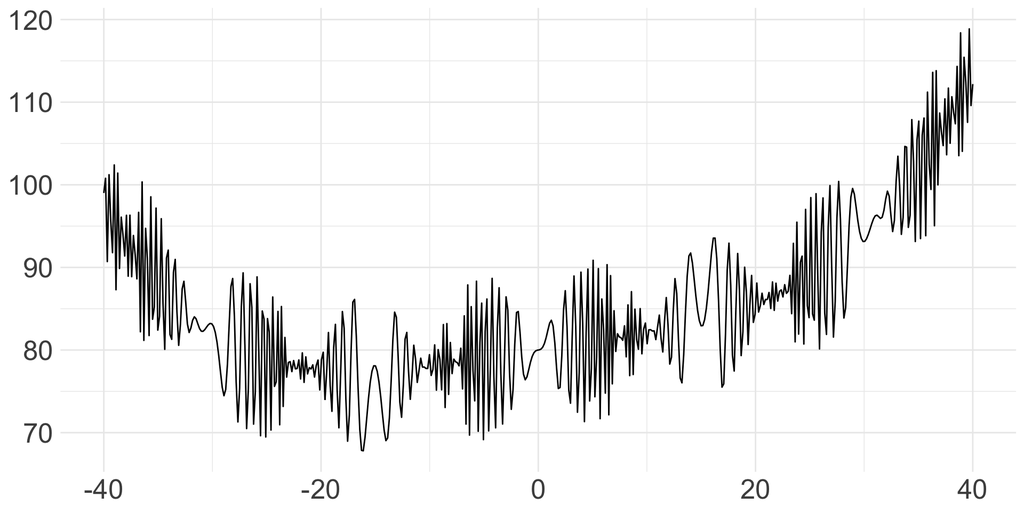

- Use `optim()` to find an approximate global minimum
- Use `optim()` again to improve locally (aiming for an objective of 67.46773).

## Your turn! Q2

- Take a look at the introduction to the Wikipedia page for [Rosenbrock’s banana function](https://en.wikipedia.org/wiki/Rosenbrock_function)
- Copy this code for the `fn` and `gr`

```r
fn <- function(x) {
    x1 <- x[1]
    x2 <- x[2]
    100 * (x2 - x1 * x1)^2 + (1 - x1)^2
}

gr <- function(x) {
    x1 <- x[1]
    x2 <- x[2]
    c(-400 * x1 * (x2 - x1 * x1) - 2 * (1 - x1),
       200 *      (x2 - x1 * x1))
}
```

- Using a start value of `c(0, 0)`, experiment with the `optim()` function to see which methods converge

# Minute card feedback

What worked well today and what could be improved?

[Go to form](https://docs.google.com/forms/d/e/1FAIpQLScq-5LxSAhNT8jURe7xlyqMjhGfTg5MbR9L4-xRN12A7L0gNg/viewform?usp=dialog)

# End matter

## Resources

This material is reproduced in large part directly from the APTS 2013/14 resources by Ruth Ripley:

- https://portal.stats.ox.ac.uk/userdata/ruth/APTS2013/Rcourse5.pdf

## License

Licensed under a Creative Commons Attribution-NonCommercial-ShareAlike 4.0 International License ([CC BY-NC-SA 4.0](https://creativecommons.org/licenses/by-nc-sa/4.0/)).